# PmagPy Command Line Version

## find_ei.py

[[notebook version]](http://pmagpy.github.io/PmagPy_plots_analysis.html#find_ei)

```python
!find_ei.py -f data_files/find_EI/find_EI_example.dat -fmt png -sav -n 300
```

```
Bootstrapping.... be patient
25  out of  300
50  out of  300
75  out of  300
100  out of  300
125  out of  300
150  out of  300
175  out of  300
200  out of  300
225  out of  300
250  out of  300
275  out of  300
300  out of  300
1  saved in  findEI_eq.png
2  saved in  findEI_ei.png
3  saved in  findEI_cdf.png
4  saved in  findEI_v2.png
```

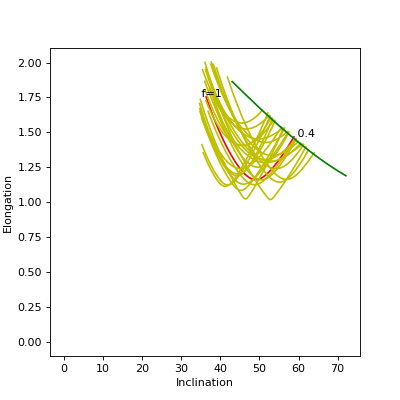

```python
Image(filename='findEI_ei.png')
```

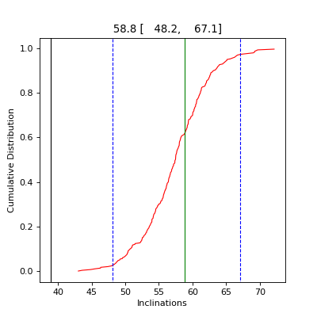

```python
Image(filename='findEI_cdf.png')
```

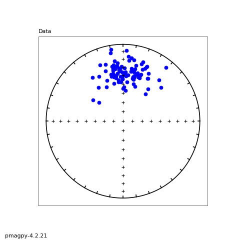

```python
Image(filename='findEI_eq.png')
```

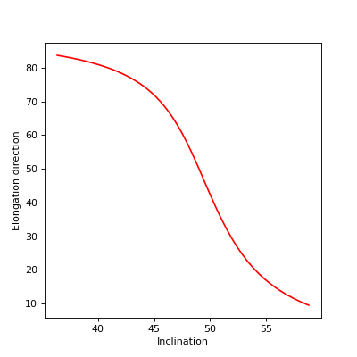

```python
Image(filename='findEI_v2.png')
```

## fisher.py

[[notebook version]](http://pmagpy.github.io/PmagPy_calculations.html#fisher)

```python
!fisher.py -k 30 -n 10
```

```
   97.4    73.8
   94.1    69.9
  317.3    75.0
  314.3    71.1
  302.3    75.9
  218.0    72.9
  182.3    86.6
  305.7    80.7
  210.1    85.0
  236.9    69.1
```

## fishqq.py

[[notebook version]](http://pmagpy.github.io/PmagPy_plots_analysis.html#fishqq)

```python
!fishqq.py -f data_files/fishqq/fishqq_example.txt -fmt png -sav
```

```
1  saved in  data_files-fishqq-fishqq_example.txt_unf1.png
2  saved in  data_files-fishqq-fishqq_example.txt_exp1.png
```

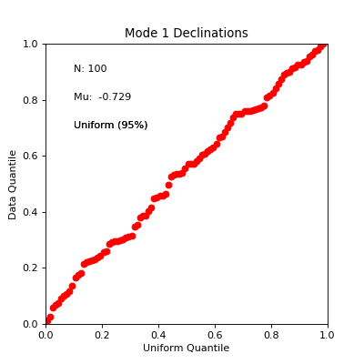

```python
Image(filename='data_files-fishqq-fishqq_example.txt_unf1.png')
```

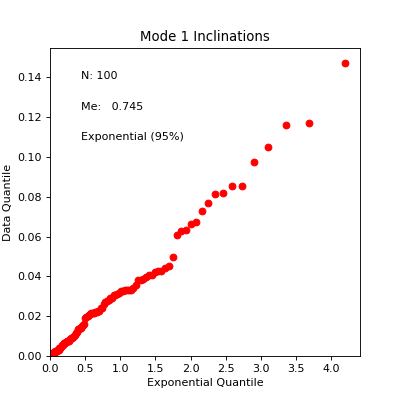

```python
Image(filename='data_files-fishqq-fishqq_example.txt_exp1.png')
```

## fishrot.py

[[notebook version]](http://pmagpy.github.io/PmagPy_calculations.html#fishrot)

```python
!fishrot.py -n 5 -D 33 -I 41 -k 50
```

```
  352.5    38.8
   15.7    40.5
   51.5    51.1
   51.2    43.5
   42.2    45.2
```

## foldtest.py

[[notebook version]](http://pmagpy.github.io/PmagPy_plots_analysis.html#foldtest)

```python
!foldtest.py -f data_files/foldtest/foldtest_example.dat -fmt png -sav -n 300
```

```
doing  300  iterations...please be patient.....
0
50
100
150
200
250
81 - 118 Percent Unfolding
range of all bootstrap samples:  78  -  129
1  saved in  foldtest_ge.png
2  saved in  foldtest_st.png
3  saved in  foldtest_ta.png
```

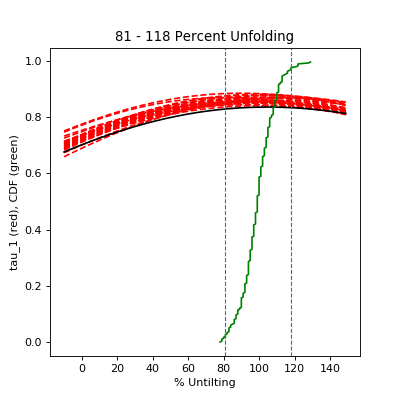

```python
Image(filename='foldtest_ta.png')
```

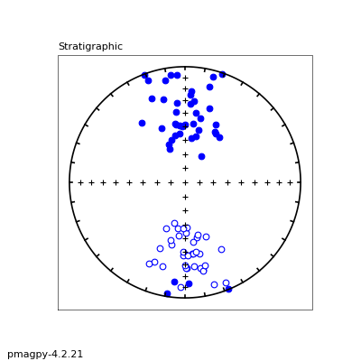

```python
Image(filename='foldtest_st.png')
```

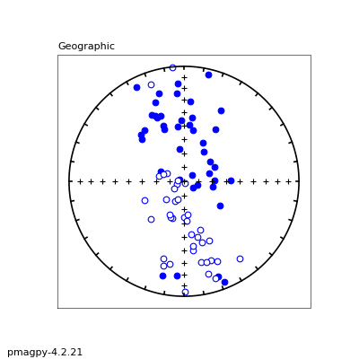

```python
Image(filename='foldtest_ge.png')
```

## foldtest_magic.py

[[notebook version]](http://pmagpy.github.io/PmagPy_plots_analysis.html#foldtest_magic)

```python
!foldtest_magic.py -f data_files/foldtest_magic/sites.txt -fmt png -sav -DM 3 -n 300 -exc
```

```
doing  300  iterations...please be patient.....
0
50
100
150
200
250
27 - 94 Percent Unfolding
1  saved in  foldtest_ge.png
2  saved in  foldtest_st.png
3  saved in  foldtest_ta.png
```

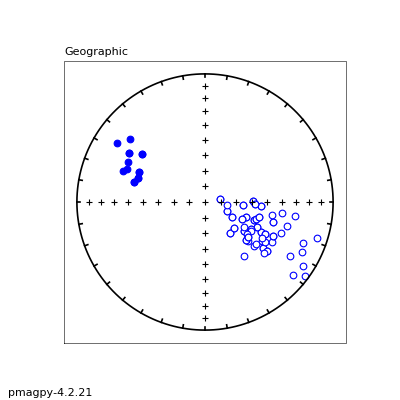

```python
Image(filename='foldtest_ge.png')
```

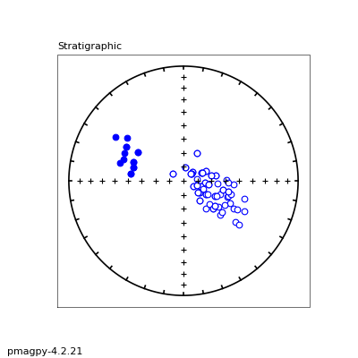

```python
Image(filename='foldtest_st.png')
```

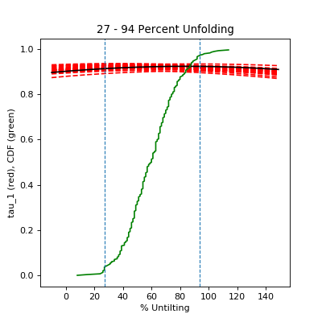

```python
Image(filename='foldtest_ta.png')
```

## forc_diagram.py

[[notebook version]](http://pmagpy.github.io/PmagPy_plots_analysis.html#forc_diagram)

```
1  saved in  forc.png
```

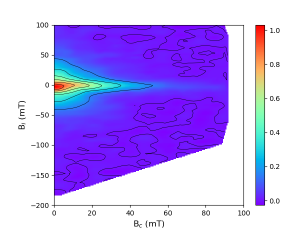

```python
!forc_diagram.py -f data_files/forc_diagram/conventional_example.forc -sf 3 -sav -fmt png
Image('forc.png')
```

## gaussian.py

[[notebook version]](http://pmagpy.github.io/PmagPy_calculations.html#gaussian)

```python
!gaussian.py -s 3 -n 1000 -m 10. -F data_files/gaussian/gaussian.out
!histplot.py -f data_files/gaussian/gaussian.out -fmt png -sav
```

```
normalizing
plot saved in  hist.png
```

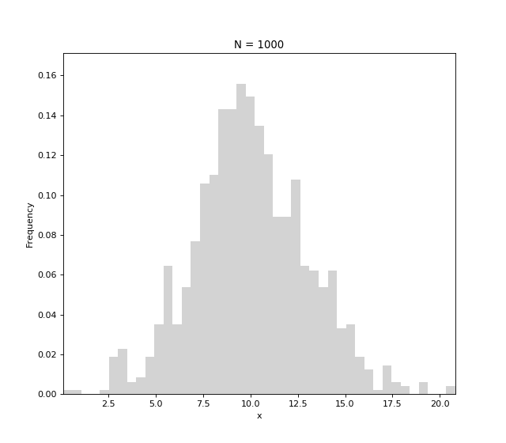

```python
Image(filename='hist.png')
```

## generic_magic.py

[[notebook version]](http://pmagpy.github.io/PmagPy_MagIC.html#generic_magic)

```python
!generic_magic.py -f data_files/convert_2_magic/generic_magic/generic_magic_example.txt -exp PI
```

```
-I- Using online data model
-I- Getting method codes from earthref.org
-I- Using cached vocabularies
adding measurement column to measurements table!
-I- overwriting /Users/nebula/Python/PmagPy/measurements.txt
-I- 23 records written to measurements file
-I- overwriting /Users/nebula/Python/PmagPy/specimens.txt
-I- 2 records written to specimens file
-I- overwriting /Users/nebula/Python/PmagPy/samples.txt
-I- 2 records written to samples file
-I- overwriting /Users/nebula/Python/PmagPy/sites.txt
-I- 2 records written to sites file
-I- overwriting /Users/nebula/Python/PmagPy/locations.txt
-I- 1 records written to locations file
-I- overwriting /Users/nebula/Python/PmagPy/measurements.txt
-I- 23 records written to measurements file
```

## gobing.py

[[notebook version]](http://pmagpy.github.io/PmagPy_calculations.html#gobing)

```python
!gobing.py -f data_files/gobing/gobing_example.txt
```

```
  357.8    60.3     4.5   105.7    10.0     4.5    21.0   -27.6 20
```

## gofish.py

[[notebook version]](http://pmagpy.github.io/PmagPy_calculations.html#gofish)

```python
!gofish.py -f data_files/gofish/fishrot.out
```

```
   10.8    39.6    10     9.8484     59.4     6.3    10.5
```

## gokent.py

[[notebook version]](http://pmagpy.github.io/PmagPy_calculations.html#gokent)

```python
!gokent.py -f data_files/gokent/gokent_example.txt
```

```
  359.2    55.0     9.3   147.7    30.8     7.8   246.8    14.9 20
```

## goprinc.py

[[notebook version]](http://pmagpy.github.io/PmagPy_calculations.html#goprinc)

```python
!goprinc.py -f data_files/goprinc/tk03.out
```

```
0.93863    11.0    58.6 0.04258   226.4    26.5 0.01879   128.3    15.6 20
```

## grab_magic_key.py

[[notebook version]](http://pmagpy.github.io/PmagPy_MagIC.html#grab_magic_key)

```python
!grab_magic_key.py -f data_files/download_magic/sites.txt -key lat
```

```
42.60264
42.60264
42.6026
42.60352
42.6035
42.60104000000001
42.601000000000006
42.73656
42.7366
42.8418
42.8418
42.8657
42.8657
42.92031
42.9203
42.56857
42.49964
42.49962
42.4996
42.50001
42.5
42.52872
42.5287
42.45559
42.4556
42.48923
42.4892
42.46186
42.4619
42.69156
42.65289
42.6529
43.30504000000001
43.305
43.36817
43.36817
43.3682
43.42133
43.4213
43.8859
43.8859
43.8859
43.84273
43.8427
43.53289
43.57494000000001
43.57494000000001
43.5749
44.15663
44.1566
44.18629
42.6026
```

## histplot.py

see [gaussian.py]

[[notebook version (gaussian example)]](http://pmagpy.github.io/PmagPy_calculations.html#gaussian)

## huji_magic.py

[[notebook version]](http://pmagpy.github.io/PmagPy_MagIC.html#huji_magic)

```python
!huji_magic.py -f data_files/convert_2_magic/HUJI_magic/Massada_AF_HUJI_new_format.txt -LP T
```

```
-W- Identical treatments in file data_files/convert_2_magic/HUJI_magic/Massada_AF_HUJI_new_format.txt magfile line 818: specimen M5-119E, treatment 0 ignoring the first.
-I- done reading file data_files/convert_2_magic/HUJI_magic/Massada_AF_HUJI_new_format.txt
-I- Using cached data model
-I- Getting method codes from earthref.org
-I- Importing controlled vocabularies from https://earthref.org
-I- Using cached suggested vocabularies
adding measurement column to measurements table!
-I- overwriting /Users/nebula/Python/PmagPy/measurements.txt
-I- 616 records written to measurements file
-I- overwriting /Users/nebula/Python/PmagPy/specimens.txt
-I- 56 records written to specimens file
-I- overwriting /Users/nebula/Python/PmagPy/samples.txt
-I- 56 records written to samples file
-I- overwriting /Users/nebula/Python/PmagPy/sites.txt
-I- 29 records written to sites file
-I- overwriting /Users/nebula/Python/PmagPy/locations.txt
-I- 1 records written to locations file
-I- overwriting /Users/nebula/Python/PmagPy/measurements.txt
-I- 616 records written to measurements file
```

## huji_sample_magic.py

[[notebook version]](http://pmagpy.github.io/PmagPy_MagIC.html#huji_sample_magic)

```python
!huji_sample_magic.py -f data_files/convert_2_magic/HUJI_magic/magdelkrum_datafile.txt
```

```
-I- reading in: /Users/nebula/Python/PmagPy/data_files/convert_2_magic/HUJI_magic/magdelkrum_datafile.txt
57  records written to file  /Users/nebula/Python/PmagPy/samples.txt
57  records written to file  /Users/nebula/Python/PmagPy/sites.txt
Sample info saved in  /Users/nebula/Python/PmagPy/samples.txt
Site info saved in  /Users/nebula/Python/PmagPy/sites.txt
```

## hysteresis_magic.py

[[notebook version]](http://pmagpy.github.io/PmagPy_plots_analysis.html#hysteresis_magic)

```python
# for MagIC data model 3:
!hysteresis_magic.py -ID data_files/hysteresis_magic/ -f measurements.txt \
    -spc IS06a-1  -fmt png -sav
```

```
1  saved in  /Users/nebula/Python/PmagPy/IS06a-1_hyst.png
2  saved in  /Users/nebula/Python/PmagPy/IS06a-1_deltaM.png
3  saved in  /Users/nebula/Python/PmagPy/IS06a-1_DdeltaM.png
1  saved in  /Users/nebula/Python/PmagPy/IS06a-1_irm.png
-I- Using online data model
-I- Couldn't connect to earthref.org, using cached method codes
-I- Using cached method codes
-I- Importing controlled vocabularies from https://earthref.org
-I- Using cached suggested vocabularies
-I- overwriting /Users/nebula/Python/PmagPy/specimens.txt
-I- 10 records written to specimens file
```

[figure not shown]

```python
Image(filename='IS06a-1_hyst.png')
```

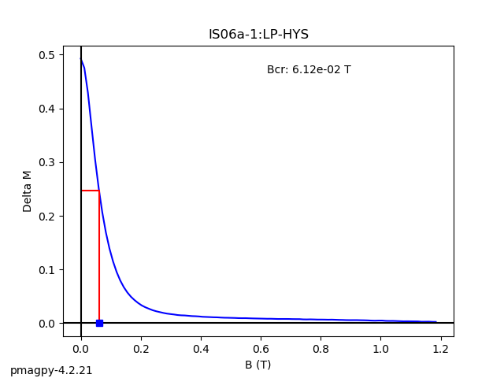

```python
Image('IS06a-1_deltaM.png')
```

```python
!hysteresis_magic.py -ID data_files/hysteresis_magic/ -f measurements.txt \
    -spc IS06a-1  -fmt png -sav
```

```
1  saved in  /Users/nebula/Python/PmagPy/IS06a-1_hyst.png
2  saved in  /Users/nebula/Python/PmagPy/IS06a-1_deltaM.png
3  saved in  /Users/nebula/Python/PmagPy/IS06a-1_DdeltaM.png
1  saved in  /Users/nebula/Python/PmagPy/IS06a-1_irm.png
-I- Using online data model
-I- Getting method codes from earthref.org
-I- Using cached vocabularies
-I- overwriting /Users/nebula/Python/PmagPy/specimens.txt
-I- 10 records written to specimens file
```

[figure not shown]

```python
Image(filename='IS06a-1_hyst.png')
```

## iodp_dscr_magic.py

```python
!iodp_dscr_magic.py -f data_files/convert_2_magic/IODP_srm_magic/IODP_LIMS_SRMdiscrete_344_1414A.csv
```

```
processing:  /Users/nebula/Python/PmagPy/data_files/convert_2_magic/IODP_srm_magic/IODP_LIMS_SRMdiscrete_344_1414A.csv
-I- Using cached data model
-I- Getting method codes from earthref.org
-I- Importing controlled vocabularies from https://earthref.org
adding measurement column to measurements table!
-I- overwriting /Users/nebula/Python/PmagPy/measurements.txt
-I- 112 records written to measurements file
-I- overwriting /Users/nebula/Python/PmagPy/specimens.txt
-I- 56 records written to specimens file
-I- overwriting /Users/nebula/Python/PmagPy/samples.txt
-I- 32 records written to samples file
-I- overwriting /Users/nebula/Python/PmagPy/sites.txt
-I- 1 records written to sites file
-I- overwriting /Users/nebula/Python/PmagPy/locations.txt
-I- 1 records written to locations file
-I- overwriting /Users/nebula/Python/PmagPy/measurements.txt
-I- 112 records written to measurements file
```

## iodp_jr6_magic.py

```python
!iodp_jr6_magic.py -f data_files/convert_2_magic/IODP_jr6_magic/test.jr6
```

```
-I- Using online data model
-I- Getting method codes from earthref.org
-I- Importing controlled vocabularies from https://earthref.org
adding measurement column to measurements table!
-I- overwriting /Users/nebula/Python/PmagPy/measurements.txt
-I- 1 records written to measurements file
-I- overwriting /Users/nebula/Python/PmagPy/specimens.txt
-I- 1 records written to specimens file
-I- overwriting /Users/nebula/Python/PmagPy/samples.txt
-I- 1 records written to samples file
-I- overwriting /Users/nebula/Python/PmagPy/sites.txt
-I- 1 records written to sites file
-I- overwriting /Users/nebula/Python/PmagPy/locations.txt
-I- 1 records written to locations file
-I- overwriting /Users/nebula/Python/PmagPy/measurements.txt
-I- 1 records written to measurements file
```

## iodp_srm_magic.py

```python
!iodp_srm_magic.py -f data_files/convert_2_magic/iodp_srm_magic/SRM_318_U1359_B_A.csv
```

[output not shown]

## igrf.py

[[notebook version]](http://pmagpy.github.io/PmagPy_calculations.html#igrf)

```python
!igrf.py -ages -3000 1950 50 -loc 33 -117 -mod pfm9k -plt -fmt png -sav
```

```
Figure saved as:  igrf.png
```

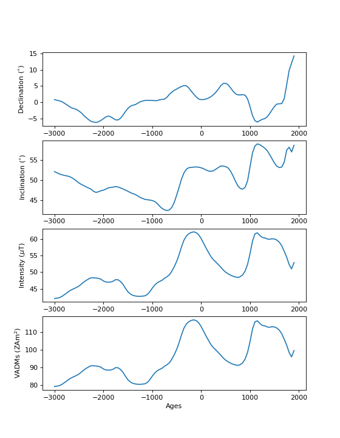

```python
Image(filename='igrf.png')
```

## install_etopo.py

```python
# install high resolution maps, only used for Basemap
!install_etopo.py
```

```
-I- Some mapping utilities use the Etopo package for topography and these data sets do not come standard with the Python installation of Basemap.  However, if you are using cartopy for plotting (recommended), you do not need to run install_etopo.py.
-E- Basemap does not appear to be installed, aborting program...
```

## incfish.py

[[notebook version]](http://pmagpy.github.io/PmagPy_calculations.html#incfish)

```python
!incfish.py -f data_files/incfish/incfish_example_inc.dat
```

```
   57.1    61.0  100     92.9    13.9     1.0
```

## irmaq_magic.py

[[notebook version]](http://pmagpy.github.io/PmagPy_plots_analysis.html#irmaq_magic)

```python
!sio_magic.py -f data_files/irmaq_magic/U1359A_IRM_coil2.txt -LP I -V 2 \
    -WD data_files/irmaq_magic/ -F U1359A_IRM_coil2.magic -loc U1359A -spc 0 -ncn 5 \
    -Fsp coil2_specimens.txt -Fsa coil2_samples.txt -Fsi coil2_sites.txt -Flo coil2_locations.txt

!sio_magic.py -f data_files/irmaq_magic/U1359A_IRM_coil3.txt -LP I -V 3 \
    -WD data_files/irmaq_magic/ -F U1359A_IRM_coil3.magic -loc U1359A -spc 0 -ncn 5 \
    -Fsp coil3_specimens.txt -Fsa coil3_samples.txt -Fsi coil3_sites.txt -Flo coil3_locations.txt

!combine_magic.py -F data_files/irmaq_magic/measurements.txt \
    -f data_files/irmaq_magic/U1359A_IRM_coil2.magic \
    data_files/irmaq_magic/U1359A_IRM_coil3.magic -dm 3

!combine_magic.py -F measurements.txt -WD data_files/irmaq_magic \
    -f U1359A_IRM_coil2.magic U1359A_IRM_coil3.magic -dm 3

!combine_magic.py -F specimens.txt -WD data_files/irmaq_magic \
    -f coil2_specimens.txt coil3_specimens.txt

!combine_magic.py -F samples.txt -WD data_files/irmaq_magic \
    -f coil2_samples.txt coil3_samples.txt

!combine_magic.py -F sites.txt -WD data_files/irmaq_magic \
    -f coil2_sites.txt coil3_sites.txt

!combine_magic.py -F locations.txt -WD data_files/irmaq_magic \
    -f coil2_locations.txt coil3_locations.txt
```

```
-I- Using online data model
-I- Getting method codes from earthref.org
-I- Importing controlled vocabularies from https://earthref.org
-I- Using cached suggested vocabularies
adding measurement column to measurements table!
-I- overwriting /Users/nebula/Python/PmagPy/measurements.txt
-I- 536 records written to measurements file
-I- writing specimens records to /Users/nebula/Python/PmagPy/data_files/irmaq_magic/coil2_specimens.txt
-I- 49 records written to specimens file
-I- writing samples records to /Users/nebula/Python/PmagPy/data_files/irmaq_magic/coil2_samples.txt
-I- 49 records written to samples file
-I- writing sites records to /Users/nebula/Python/PmagPy/data_files/irmaq_magic/coil2_sites.txt
-I- 49 records written to sites file
-I- writing locations records to /Users/nebula/Python/PmagPy/data_files/irmaq_magic/coil2_locations.txt
-I- 1 records written to locations file
-I- writing measurements records to /Users/nebula/Python/PmagPy/data_files/irmaq_magic/U1359A_IRM_coil2.magic
-I- 536 records written to measurements file
-I- Using cached data model
-I- Getting method codes from earthref.org
-I- Using cached vocabularies
adding measurement column to measurements table!
-I- overwriting /Users/nebula/Python/PmagPy/measurements.txt
-I- 23 records written to measurements file
-I- writing specimens records to /Users/nebula/Python/PmagPy/data_files/irmaq_magic/coil3_specimens.txt
-I- 14 records written to specimens file
-I- writing samples records to /Users/nebula/Python/PmagPy/data_files/irmaq_magic/coil3_samples.txt
-I- 14 records written to samples file
-I- writing sites records to /Users/nebula/Python/PmagPy/data_files/irmaq_magic/coil3_sites.txt
-I- 14 records written to sites file
-I- writing locations records to /Users/nebula/Python/PmagPy/data_files/irmaq_magic/coil3_locations.txt
-I- 1 records written to locations file
-I- writing measurements records to /Users/nebula/Python/PmagPy/data_files/irmaq_magic/U1359A_IRM_coil3.magic
-I- 23 records written to measurements file
Using default arguments for: -A, -WD, -ID, -Fsa, -Fsi
-I- Using cached data model
-I- Couldn't connect to earthref.org, using cached method codes
-I- Using cached method codes
-I- Importing controlled vocabularies from https://earthref.org
-I- overwriting /Users/nebula/Python/PmagPy/data_files/irmaq_magic/measurements.txt
-I- 559 records written to measurements file
```

[output cut: 18 more lines]

```
-I- Importing controlled vocabularies from https://earthref.org
-I- writing samples records to /Users/nebula/Python/PmagPy/data_files/irmaq_magic/samples.txt
-I- 63 records written to samples file
Using default arguments for: -A, -ID, -Fsa, -Fsi, -dm
-I- Using online data model
-I- Getting method codes from earthref.org
-I- Using cached vocabularies
-I- writing sites records to /Users/nebula/Python/PmagPy/data_files/irmaq_magic/sites.txt
-I- 63 records written to sites file
Using default arguments for: -A, -ID, -Fsa, -Fsi, -dm
-I- Using cached data model
-I- Getting method codes from earthref.org
-I- Using cached vocabularies
-I- writing locations records to /Users/nebula/Python/PmagPy/data_files/irmaq_magic/locations.txt
-I- 1 records written to locations file
```

```python
!irmaq_magic.py -f data_files/irmaq_magic/measurements.txt -fmt png -sav -DM 3
```

```
-W- You are trying to plot measurements by location
    By default, this information is not available in your measurement file.
    Trying to acquire this information from /Users/nebula/Python/PmagPy/data_files/irmaq_magic
-I- Using online data model
-I- Getting method codes from earthref.org
-I- Importing controlled vocabularies from https://earthref.org
-I- Found location information, continuing with plotting
U1359A
1  saved in  U1359A_LP-IRM.png
```

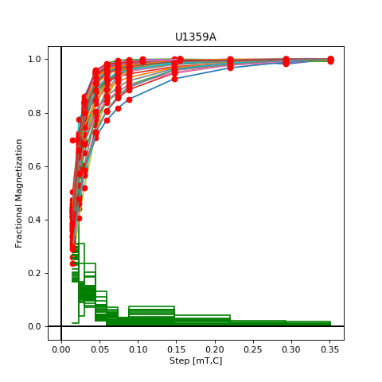

```python
Image("U1359A_LP-IRM.png")
```

## jr6_jr6_magic.py

[[notebook version]](http://pmagpy.github.io/PmagPy_MagIC.html#jr6_jr6_magic)

```python
!jr6_jr6_magic.py -f data_files/convert_2_magic/JR6_magic/AF.jr6
```

```
-I- Using cached data model
-I- Getting method codes from earthref.org
-I- Importing controlled vocabularies from https://earthref.org
-I- Using cached suggested vocabularies
adding measurement column to measurements table!
-I- overwriting /Users/nebula/Python/PmagPy/measurements.txt
-I- 655 records written to measurements file
-I- overwriting /Users/nebula/Python/PmagPy/specimens.txt
-I- 57 records written to specimens file
-I- overwriting /Users/nebula/Python/PmagPy/samples.txt
-I- 17 records written to samples file
-I- overwriting /Users/nebula/Python/PmagPy/sites.txt
-I- 10 records written to sites file
-I- overwriting /Users/nebula/Python/PmagPy/locations.txt
-I- 1 records written to locations file
-I- overwriting /Users/nebula/Python/PmagPy/measurements.txt
-I- 655 records written to measurements file
```

## jr6_txt_magic.py

[[notebook version]](http://pmagpy.github.io/PmagPy_MagIC.html#jr6_txt_magic)

```python
!jr6_txt_magic.py -f data_files/convert_2_magic/JR6_magic/AF.txt
```

```
-I- Using less strict decoding for /Users/nebula/Python/PmagPy/data_files/convert_2_magic/JR6_magic/AF.txt, output may have formatting errors
-I- Using online data model
-I- Getting method codes from earthref.org
-I- Using cached vocabularies
-I- Using cached suggested vocabularies
adding measurement column to measurements table!
-I- overwriting /Users/nebula/Python/PmagPy/measurements.txt
-I- 655 records written to measurements file
-I- overwriting /Users/nebula/Python/PmagPy/specimens.txt
-I- 57 records written to specimens file
-I- overwriting /Users/nebula/Python/PmagPy/samples.txt
-I- 17 records written to samples file
-I- overwriting /Users/nebula/Python/PmagPy/sites.txt
-I- 10 records written to sites file
-I- overwriting /Users/nebula/Python/PmagPy/locations.txt
-I- 1 records written to locations file
-I- overwriting /Users/nebula/Python/PmagPy/measurements.txt
-I- 655 records written to measurements file
```

## k15_magic.py

[[notebook version]](http://pmagpy.github.io/PmagPy_MagIC.html#k15_magic)

```python
!k15_magic.py -WD data_files/k15_magic  -spc 0 -f data_files/k15_s/k15_example.dat -loc "Troodos Ophiolite"
```

```
Using default arguments for: -F, -A, -ID, -Fsa, -Fsi, -Fa, -Fr, -ncn, -DM
8  records written to file  /Users/nebula/Python/PmagPy/data_files/k15_magic/samples.txt
48  records written to file  /Users/nebula/Python/PmagPy/data_files/k15_magic/specimens.txt
120  records written to file  /Users/nebula/Python/PmagPy/data_files/k15_magic/measurements.txt
Data saved to: /Users/nebula/Python/PmagPy/data_files/k15_magic/measurements.txt, /Users/nebula/Python/PmagPy/data_files/k15_magic/specimens.txt, /Users/nebula/Python/PmagPy/data_files/k15_magic/samples.txt
```

```python
!k15_s.py -f data_files/k15_s/k15_example.dat
```

```
0.33146986 0.33413991 0.33439023 0.00075095 -0.00083439 -0.00016688 0.00008618
0.33335925 0.33335925 0.33328149 -0.00155521 -0.00132193 0.00116641 0.00017193
0.33097634 0.33573565 0.33328801 0.00163177 0.00013598 0.00000000 0.00018131
0.33150029 0.33465420 0.33384551 -0.00064696 -0.00056609 -0.00048522 0.00014863
0.33121986 0.33521197 0.33356816 -0.00046966 -0.00046966 -0.00086104 0.00018376
0.33179570 0.33405602 0.33414828 -0.00009226 -0.00004613 -0.00027677 0.00010474
0.33243163 0.33439898 0.33316939 0.00106564 0.00032789 0.00000000 0.00017624
0.33175478 0.33512715 0.33311808 0.00078928 0.00000000 -0.00007175 0.00011116
```

## kly4s_magic.py

[[notebook version]](http://pmagpy.github.io/PmagPy_MagIC.html#kly4s_magic)

```python
!kly4s_magic.py -f data_files/convert_2_magic/kly4s_magic/KLY4S_magic_example.dat
```

```
Using default arguments for: -F, -A, -WD, -ID, -Fsa, -Fsi, -fad, -fsa, -fsp, -Fsp, -Fa, -ocn, -usr, -loc, -ins, -spc, -ncn, -DM
anisotropy data added to specimen records
52  records written to file  /Users/nebula/Python/PmagPy/specimens.txt
specimen information written to new file: /Users/nebula/Python/PmagPy/specimens.txt
26  records written to file  /Users/nebula/Python/PmagPy/measurements.txt
measurement data saved in  /Users/nebula/Python/PmagPy/measurements.txt
26  records written to file  samples.txt
26  records written to file  sites.txt
```

## ldeo_magic.py

[[notebook version]](http://pmagpy.github.io/PmagPy_MagIC.html#ldeo_magic)

```python
!ldeo_magic.py -f data_files/convert_2_magic/LDEO_magic/ldeo_magic_example.dat
```

```
-I- Using online data model
-I- Getting method codes from earthref.org
-I- Importing controlled vocabularies from https://earthref.org
-I- Using cached suggested vocabularies
adding measurement column to measurements table!
-I- overwriting /Users/nebula/Python/PmagPy/measurements.txt
-I- 35 records written to measurements file
-I- overwriting /Users/nebula/Python/PmagPy/specimens.txt
-I- 35 records written to specimens file
-I- overwriting /Users/nebula/Python/PmagPy/samples.txt
-I- 35 records written to samples file
-I- overwriting /Users/nebula/Python/PmagPy/sites.txt
-I- 35 records written to sites file
-I- overwriting /Users/nebula/Python/PmagPy/locations.txt
-I- 1 records written to locations file
-I- overwriting /Users/nebula/Python/PmagPy/measurements.txt
-I- 35 records written to measurements file
```

# livdb_magic.py

[[notebook version]](http://pmagpy.github.io/PmagPy_MagIC.html#livdb_magic)

```python
# is a GUI and doesn't work in a notebook
# see the notebook link above for how to use convert.livdb
```

# lnp_magic.py

[[notebook version]](http://pmagpy.github.io/PmagPy_plots_analysis.html#lnp_magic)

```python
!lnp_magic.py -f data_files/lnp_magic/specimens.txt -crd g -fmt png -sav -fsa data_files/lnp_magic/samples.txt
```

```
-I- Using online data model
-I- Couldn't connect to earthref.org, using cached method codes
-I- Using cached method codes
-I- Importing controlled vocabularies from https://earthref.org
-I- Using cached suggested vocabularies
sv01
Site lines planes  kappa   a95   dec   inc
sv01 0  5     286      6.6    179.0    -54.3  4.9948
% tilt correction:  0
1  saved in  sv01_g_eqarea.png
sv02
Site lines planes  kappa   a95   dec   inc
sv02 4  2     113      6.6    338.8     38.6  5.9647
% tilt correction:  0
1  saved in  sv02_g_eqarea.png
sv03
Site lines planes  kappa   a95   dec   inc
sv03 5  3     108      5.5    344.0     53.1  7.9491
% tilt correction:  0
1  saved in  sv03_g_eqarea.png
sv04
Site lines planes  kappa   a95   dec   inc
sv04 5  0     286      4.5    346.9     50.7  4.9860
% tilt correction:  0
1  saved in  sv04_g_eqarea.png
sv05
Site lines planes  kappa   a95   dec   inc
sv05 5  3     165      4.5    164.1    -51.3  7.9667
% tilt correction:  0
1  saved in  sv05_g_eqarea.png
sv06
Site lines planes  kappa   a95   dec   inc
sv06 2  3      81      9.7    351.4    -32.0  4.9691
% tilt correction:  0
1  saved in  sv06_g_eqarea.png
sv07
Site lines planes  kappa   a95   dec   inc
sv07 7  1     318      3.1    350.3     61.8  7.9796
% tilt correction:  0
1  saved in  sv07_g_eqarea.png
```

[output cut: 149 more lines]

```
sv63
Site lines planes  kappa   a95   dec   inc
sv63 4  0     489      4.2    351.5     45.1  3.9939
% tilt correction:  0
1  saved in  sv63_g_eqarea.png
sv64
Site lines planes  kappa   a95   dec   inc
sv64 6  0     172      5.1    170.4    -51.6  5.9710
% tilt correction:  0
1  saved in  sv64_g_eqarea.png
sv65
Site lines planes  kappa   a95   dec   inc
sv65 4  1      90      8.3     31.0     54.4  4.9611
% tilt correction:  0
1  saved in  sv65_g_eqarea.png
```

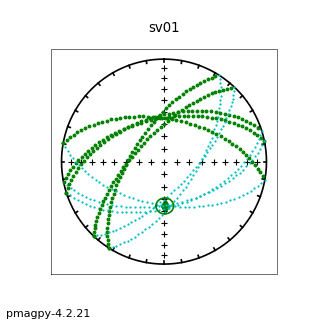

```python
Image(filename='sv01_g_eqarea.png')
```

## lowes.py

lowes.py doesn't work from within a notebook. yet.

## lowrie.py

[[notebook version]](http://pmagpy.github.io/PmagPy_plots_analysis.html#lowrie)

```python
!lowrie.py -f data_files/lowrie/lowrie_example.dat -fmt png -sav
```

```
-I- Using less strict decoding for data_files/lowrie/lowrie_example.dat, output may have formatting errors
318-U1359A-002H-1-W-109
1  saved in  lowrie__318-U1359A-002H-1-W-109_.png
318-U1359A-002H-4-W-65
1  saved in  lowrie__318-U1359A-002H-4-W-65_.png
318-U1359A-002H-6-W-7
1  saved in  lowrie__318-U1359A-002H-6-W-7_.png
318-U1359A-003H-2-W-37
1  saved in  lowrie__318-U1359A-003H-2-W-37_.png
318-U1359A-003H-6-W-66
1  saved in  lowrie__318-U1359A-003H-6-W-66_.png
318-U1359A-004H-2-W-18
1  saved in  lowrie__318-U1359A-004H-2-W-18_.png
318-U1359A-004H-2-W-44
1  saved in  lowrie__318-U1359A-004H-2-W-44_.png
318-U1359A-004H-2-W-130
1  saved in  lowrie__318-U1359A-004H-2-W-130_.png
318-U1359A-004H-3-W-100
1  saved in  lowrie__318-U1359A-004H-3-W-100_.png
318-U1359A-004H-3-W-145
1  saved in  lowrie__318-U1359A-004H-3-W-145_.png
318-U1359A-004H-4-W-102
1  saved in  lowrie__318-U1359A-004H-4-W-102_.png
318-U1359A-004H-4-W-120
1  saved in  lowrie__318-U1359A-004H-4-W-120_.png
318-U1359A-004H-5-W-139
1  saved in  lowrie__318-U1359A-004H-5-W-139_.png
318-U1359A-006H-2-W-95
1  saved in  lowrie__318-U1359A-006H-2-W-95_.png
318-U1359A-006H-6-W-22
1  saved in  lowrie__318-U1359A-006H-6-W-22_.png
318-U1359A-007H-1-W-54
1  saved in  lowrie__318-U1359A-007H-1-W-54_.png
318-U1359A-007H-2-W-125
1  saved in  lowrie__318-U1359A-007H-2-W-125_.png
318-U1359A-007H-3-W-46
1  saved in  lowrie__318-U1359A-007H-3-W-46_.png
318-U1359A-009H-6-W-31
1  saved in  lowrie__318-U1359A-009H-6-W-31_.png
318-U1359A-010H-2-W-73
```

[output cut: 12 more lines]

```
1  saved in  lowrie__318-U1359A-013H-4-W-89_.png
318-U1359A-013H-6-W-88
1  saved in  lowrie__318-U1359A-013H-6-W-88_.png
318-U1359A-014H-2-W-60
1  saved in  lowrie__318-U1359A-014H-2-W-60_.png
318-U1359A-014H-6-W-13
1  saved in  lowrie__318-U1359A-014H-6-W-13_.png
318-U1359A-015H-2-W-56
1  saved in  lowrie__318-U1359A-015H-2-W-56_.png
318-U1359A-015H-4-W-83
1  saved in  lowrie__318-U1359A-015H-4-W-83_.png
318-U1359A-018X-6-W-57
1  saved in  lowrie__318-U1359A-018X-6-W-57_.png
318-U1359A-022X-2-W-95
1  saved in  lowrie__318-U1359A-022X-2-W-95_.png
```

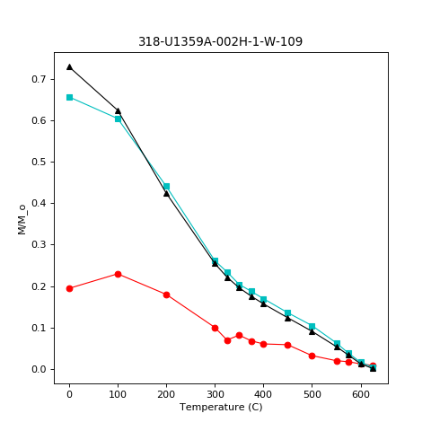

```python
Image(filename='lowrie__318-U1359A-002H-1-W-109_.png')
```

# lowrie_magic.py

[[notebook version]](http://pmagpy.github.io/PmagPy_plots_analysis.html#lowrie)

```python
!lowrie_magic.py -f data_files/lowrie_magic/measurements.txt -fmt png -sav
```

```
/Users/nebula/Python/PmagPy/data_files/lowrie_magic/measurements.txt
318-U1361A-007H-1-W-100a
1  saved in  lowrie__318-U1361A-007H-1-W-100a_.png
318-U1361A-007H-3-W-135a
1  saved in  lowrie__318-U1361A-007H-3-W-135a_.png
318-U1361A-007H-4-W-42a
1  saved in  lowrie__318-U1361A-007H-4-W-42a_.png
318-U1361A-007H-7-W-20a
1  saved in  lowrie__318-U1361A-007H-7-W-20a_.png
318-U1361A-008H-1-W-73a
1  saved in  lowrie__318-U1361A-008H-1-W-73a_.png
318-U1361A-008H-3-W-102a
1  saved in  lowrie__318-U1361A-008H-3-W-102a_.png
318-U1361A-008H-4-W-78a
1  saved in  lowrie__318-U1361A-008H-4-W-78a_.png
318-U1361A-008H-5-W-67a
1  saved in  lowrie__318-U1361A-008H-5-W-67a_.png
318-U1361A-008H-6-W-83a
1  saved in  lowrie__318-U1361A-008H-6-W-83a_.png
318-U1361A-008H-7-W-28a
1  saved in  lowrie__318-U1361A-008H-7-W-28a_.png
318-U1361A-009H-1-W-94a
1  saved in  lowrie__318-U1361A-009H-1-W-94a_.png
318-U1361A-009H-2-W-77a
1  saved in  lowrie__318-U1361A-009H-2-W-77a_.png
318-U1361A-009H-3-W-63a
1  saved in  lowrie__318-U1361A-009H-3-W-63a_.png
318-U1361A-009H-6-W-51a
1  saved in  lowrie__318-U1361A-009H-6-W-51a_.png
318-U1361A-009H-7-W-53a
1  saved in  lowrie__318-U1361A-009H-7-W-53a_.png
318-U1361A-010H-1-W-86a
1  saved in  lowrie__318-U1361A-010H-1-W-86a_.png
318-U1361A-010H-2-W-88a
1  saved in  lowrie__318-U1361A-010H-2-W-88a_.png
318-U1361A-010H-3-W-51a
1  saved in  lowrie__318-U1361A-010H-3-W-51a_.png
318-U1361A-010H-4-W-81a
1  saved in  lowrie__318-U1361A-010H-4-W-81a_.png
318-U1361A-010H-5-W-58a
```

[output cut: 52 more lines]

```
1  saved in  lowrie__318-U1361A-015H-6-W-125a_.png
318-U1361A-016H-1-W-60a
1  saved in  lowrie__318-U1361A-016H-1-W-60a_.png
318-U1361A-016H-3-W-60a
1  saved in  lowrie__318-U1361A-016H-3-W-60a_.png
318-U1361A-016H-5-W-60a
1  saved in  lowrie__318-U1361A-016H-5-W-60a_.png
318-U1361A-017X-1-W-58a
1  saved in  lowrie__318-U1361A-017X-1-W-58a_.png
318-U1361A-017X-2-W-58a
1  saved in  lowrie__318-U1361A-017X-2-W-58a_.png
318-U1361A-017X-4-W-58a
1  saved in  lowrie__318-U1361A-017X-4-W-58a_.png
318-U1361A-017X-6-W-58a
1  saved in  lowrie__318-U1361A-017X-6-W-58a_.png
```

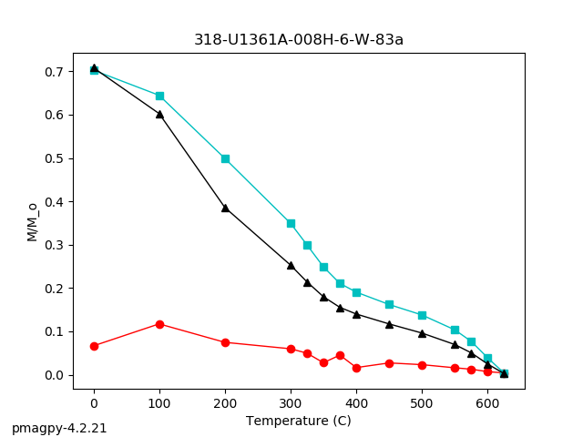

```python
Image("lowrie__318-U1361A-008H-6-W-83a_.png")
```

## magic_select.py

[[notebook version]](http://pmagpy.github.io/PmagPy_MagIC.html#magic_select)

```python
!magic_select.py -f data_files/magic_select/specimens.txt \
    -key method_codes LP-PI-TRM has -F data_files/magic_select/AF_specimens.txt
```

```
50  records written to file  ./data_files/magic_select/AF_specimens.txt
```

## mst_magic.py

[[notebook version]](http://pmagpy.github.io/PmagPy_MagIC.html#mst_magic)

```python
!mst_magic.py -f data_files/convert_2_magic/MsT_magic/curie_example.dat -spn specimen_name
```

[output not shown]

[output cut: 1077 more lines]

```
no location name for:  specimen_name
No site name found for:  specimen_name specimen_name
no location name for:  specimen_name
560  records written to file  /Users/nebula/Python/PmagPy/measurements.txt
results put in  /Users/nebula/Python/PmagPy/measurements.txt
-I- Using online data model
-I- Getting method codes from earthref.org
-I- Importing controlled vocabularies from https://earthref.org
-I- Using cached suggested vocabularies
-I- overwriting /Users/nebula/Python/PmagPy/samples.txt
-I- 35 records written to samples file
-I- overwriting /Users/nebula/Python/PmagPy/sites.txt
-I- 35 records written to sites file
-I- overwriting /Users/nebula/Python/PmagPy/locations.txt
-I- 1 records written to locations file
```

## mk_redo.py

```python
!mk_redo.py -WD data_files/mk_redo
```

```
Redo files saved to:  /Users/nebula/Python/PmagPy/data_files/mk_redo/zeq_redo /Users/nebula/Python/PmagPy/data_files/mk_redo/thellier_redo
```

```python
!cat data_files/mk_redo/thellier_redo | head
```

```
sr01a1 573 823
sr01a2 573 848
sr01c2 673 823
sr01d1 373 823
sr01i1 373 773
sr03a1 373 673
sr03b1 373 673
sr03c1 423 673
sr03e1 423 673
sr09f1 373 573
```

```python
!cat data_files/mk_redo/zeq_redo | head
```

```
sr01a1 DE-BFL 473 823 A
sr01a2 DE-BFL 473 848 A
sr01c2 DE-BFL 473 823 A
sr01d1 DE-BFL 373 798 A
sr01e2 DE-BFL 0.01 0.18 A
sr01f2 DE-BFL 423 923 A
sr01g2 DE-BFL 0.01 0.16 A
sr01i1 DE-BFL 473 823 A
sr03a1 DE-BFL 473 823 A
sr03b1 DE-BFL 673 823 A
```

## orientation_magic.py

[[notebook version]](http://pmagpy.github.io/PmagPy_MagIC.html#orientation_magic)

```python
try:
    os.remove('data_files/orientation_magic/samples.txt')
except FileNotFoundError:
    pass
!orientation_magic.py -WD data_files/orientation_magic -f orient_example.txt -gmt 13
!cat data_files/orientation_magic/samples.txt | head
```

```
Using default arguments for: -F, -A, -ID, -Fsa, -Fsi, -app, -ocn, -dcn, -BCN, -ncn, -mcd, -a, -DM
setting location name to ""
setting location name to ""
saving data...
24  records written to file  /Users/nebula/Python/PmagPy/data_files/orientation_magic/samples.txt
2  records written to file  /Users/nebula/Python/PmagPy/data_files/orientation_magic/sites.txt
Data saved in  /Users/nebula/Python/PmagPy/data_files/orientation_magic/samples.txt  and  /Users/nebula/Python/PmagPy/data_files/orientation_magic/sites.txt
tab 	samples
azimuth	azimuth_dec_correction	bed_dip	bed_dip_direction	citations	cooling_rate	cooling_rate_corr	cooling_rate_mcd	description	dip	geologic_classes	geologic_types	height	igsn	lat	lithologies	location	lon	method_codes	orientation_quality	sample	sample_alternatives	scientists	site	texture	timestamp
258.0		4	162.3	This study					-38.0					-78.25435		McMurdo	163.72913	SO-MAG		mc123a			mc123		2004:1:15:16:58
48.3	150.3	4	162.3	This study				Declination correction calculated from IGRF	-38.0					-78.25435		McMurdo	163.72913	SO-CMD-NORTH		mc123a			mc123		2004:1:15:16:58
35.8		4	162.3	This study					-38.0					-78.25435		McMurdo	163.72913	SO-SUN		mc123a			mc123		2004:1:15:16:58
242.0		4		This study					-30.0					-78.25435		McMurdo	163.72913	SO-MAG		mc123b			mc123
32.3	150.3	4		This study				Declination correction calculated from IGRF	-30.0					-78.25435		McMurdo	163.72913	SO-CMD-NORTH		mc123b			mc123
18.2		4		This study					-30.0					-78.25435		McMurdo	163.72913	SO-SUN		mc123b			mc123
266.0		4		This study					-39.0					-78.25435		McMurdo	163.72913	SO-MAG		mc123c			mc123
56.3	150.3	4		This study				Declination correction calculated from IGRF	-39.0					-78.25435		McMurdo	163.72913	SO-CMD-NORTH		mc123c			mc123
```

## pca.py

[[notebook version]](http://pmagpy.github.io/PmagPy_calculations.html#pca)

```python
!pca.py -dir L 1 10 -f data_files/pca/pca_example.txt
```

```
eba24a DE-BFL
0 0.00 339.9 57.9 9.2830e-05
1 2.50 325.7 49.1 7.5820e-05
2 5.00 321.3 45.9 6.2920e-05
3 10.00 314.8 41.7 5.2090e-05
4 15.00 310.3 38.7 4.4550e-05
5 20.00 305.0 37.0 3.9540e-05
6 30.00 303.9 34.7 3.2570e-05
7 40.00 303.0 32.3 2.5670e-05
8 50.00 303.6 32.4 2.2520e-05
9 60.00 299.8 30.8 1.9820e-05
10 70.00 292.5 31.0 1.3890e-05
11 80.00 297.0 25.6 1.2570e-05
12 90.00 299.3 11.3 0.5030e-05
eba24a DE-BFL 10    2.50  70.00    8.8   334.9    51.5
```

## pmd_magic.py

[[notebook version]](http://pmagpy.github.io/PmagPy_MagIC.html#pmd_magic)

```python
!pmd_magic.py -f data_files/convert_2_magic/pmd_magic/PMD/ss0207a.pmd
```

```
-I- Using online data model
-I- Getting method codes from earthref.org
-I- Importing controlled vocabularies from https://earthref.org
-I- Using cached suggested vocabularies
adding measurement column to measurements table!
-I- overwriting /Users/nebula/Python/PmagPy/measurements.txt
-I- 8 records written to measurements file
-I- overwriting /Users/nebula/Python/PmagPy/specimens.txt
-I- 1 records written to specimens file
-I- overwriting /Users/nebula/Python/PmagPy/samples.txt
-I- 1 records written to samples file
-I- overwriting /Users/nebula/Python/PmagPy/sites.txt
-I- 1 records written to sites file
-I- overwriting /Users/nebula/Python/PmagPy/locations.txt
-I- 1 records written to locations file
-I- overwriting /Users/nebula/Python/PmagPy/measurements.txt
-I- 8 records written to measurements file
```

## plotxy.py

```python
!plotxy.py -f data_files/plotXY/plotXY_example.txt -fmt png -sav
```

```
Figure saved as  plotXY.png
```

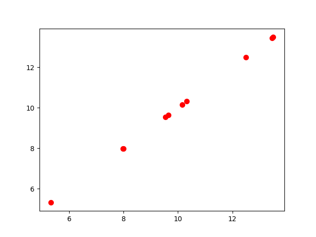

```python
Image(filename='plotXY.png')
```

## plot_cdf.py

[[notebook version]](http://pmagpy.github.io/PmagPy_plots_analysis.html#plot_cdf)

```python
!plot_cdf.py -f data_files/plot_cdf/gaussian.out -fmt png -sav
```

```
1  saved in  CDF_.png
```

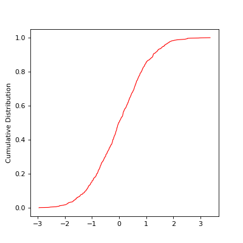

```python
Image(filename='CDF_.png')
```

## plot_geomagia.py

see [[notebook version]](http://pmagpy.github.io/PmagPy_plots_analysis.html#plot_geomagia)

## plot_magmap.py

[[notebook version]](http://pmagpy.github.io/PmagPy_plots_analysis.html#plot_mag_map)

```python
!plot_magmap.py -el B -fmt png -sav
```

```
Figure saved as:  geomagnetic_field_2016.0.png
```

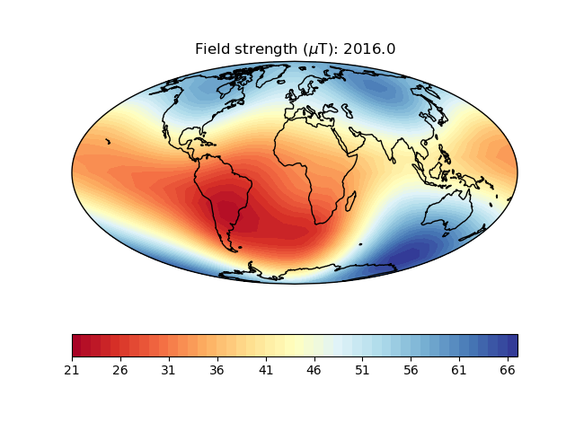

```python
image = None
if cartopy_present:
    image = Image('geomagnetic_field_2016.0.png')
image
```

## plot_map_pts.py

[[notebook version]](http://pmagpy.github.io/PmagPy_plots_analysis.html#plot_map_pts)

```python
!plot_map_pts.py -f data_files/plot_map_pts/uniform.out -B -R \
    -prj ortho -eye 30 0 -etp -sym wo 10 -fmt png -sav
```

```
-W- plotting will require patience!
please wait to draw points
gridlines only supported for PlateCarree, Lambert Conformal, and Mercator plots currently
1  saved in  map_pts.png
```

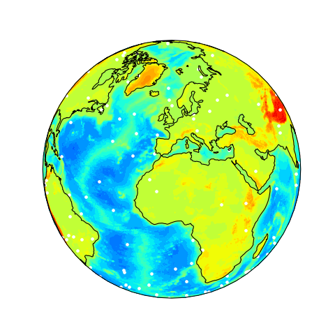

```python
image = None
if cartopy_present:
    image = Image(filename='map_pts.png')
image
```

## plotdi_a.py

[[notebook version]](http://pmagpy.github.io/PmagPy_plots_analysis.html#plotdi_a)

```python
!plotdi_a.py -f data_files/plotdi_a/plotdi_a_example.dat -fmt png -sav
```

```
1  saved in  eq.png
```

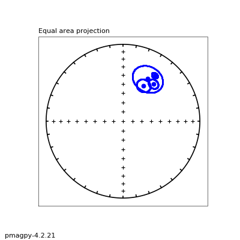

```python
Image(filename='eq.png')
```

## pmag_results_extract.py

```python
!pmag_results_extract.py -WD data_files/pmag_results_extract -f pmag_results.txt
```

```
data saved in:  /Users/nebula/Python/PmagPy/data_files/pmag_results_extract/Directions.txt /Users/nebula/Python/PmagPy/data_files/pmag_results_extract/Intensities.txt /Users/nebula/Python/PmagPy/data_files/pmag_results_extract/SiteNfo.txt
```

## polemap_magic.py

[[notebook version]](http://pmagpy.github.io/PmagPy_plots_analysis.html#polemap_magic)

```python
!polemap_magic.py -WD data_files/polemap_magic -sav -fmt png
```

```
-I- Using cached data model
-I- Couldn't connect to earthref.org, using cached method codes
-I- Using cached method codes
-I- Importing controlled vocabularies from https://earthref.org
1  saved in  Cismon Section_Monte Raparo Limestones_Algarve Bas_POLE_map_t.png
```

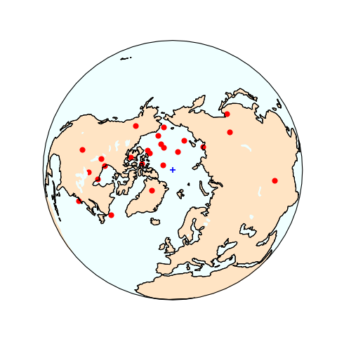

```python
image = None
if cartopy_present:
    image = Image(filename="Cismon Section_Monte Raparo Limestones_Algarve Bas_POLE_map_t.png")
image
```

## pt_rot.py

[[notebook version]](http://pmagpy.github.io/PmagPy_calculations.html#pt_rot)

```python
!awk '{print $1,$2}' data_files/pt_rot/pt_rot.input > data_files/pt_rot/lon_lat
!plot_map_pts.py -prj moll -f data_files/pt_rot/lon_lat -sym g^ 20 -R -B -eye 0 0 -fmt png -sav
```

```
please wait to draw points
gridlines only supported for PlateCarree, Lambert Conformal, and Mercator plots currently
1  saved in  map_pts.png
```

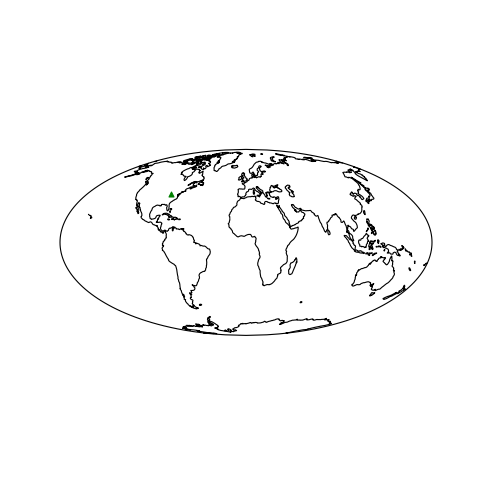

```python
image
if cartopy_present:
    image = Image(filename='map_pts.png')

image
```

```python
!cat data_files/pt_rot/pt_rot.input
!pt_rot.py -f data_files/pt_rot/pt_rot.input > data_files/pt_rot/pt_rot.out
```

```
-84.7 39.1 nam 80 saf
```

```python
!plot_map_pts.py -prj moll -f data_files/pt_rot/pt_rot.out -sym ro 20 -R -B -eye 0 0 -fmt png -sav
```

```
please wait to draw points
gridlines only supported for PlateCarree, Lambert Conformal, and Mercator plots currently
1  saved in  map_pts.png
```

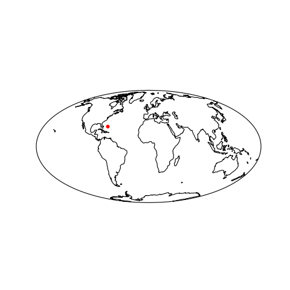

```python
if cartopy_present:
    image = Image(filename='map_pts.png')
image
```

Something still weird about pt_rot.py (the -ff option).

```python
!pt_rot.py -ff data_files/pt_rot/nam_180-200.txt data_files/pt_rot/nam_panA.frp > data_files/pt_rot/pt_rot_panA.out
```

```python
!plot_map_pts.py -f data_files/pt_rot/pt_rot_panA.out -prj ortho -eye 60 90 -sym ro 10 -B -R -fmt png -sav
```

```
please wait to draw points
gridlines only supported for PlateCarree, Lambert Conformal, and Mercator plots currently
1  saved in  map_pts.png
```

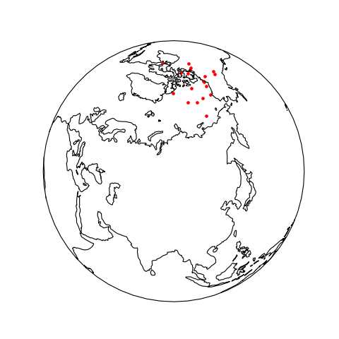

```python
image = None
if cartopy_present:
    image = Image(filename='Map_pts.png')
image
```

## qqplot.py

[[notebook version]](http://pmagpy.github.io/PmagPy_plots_analysis.html#qqplot)

```python
!qqplot.py -f data_files/qqplot/gauss.out -fmt png -sav
```

```
1  saved in  qq.png
```

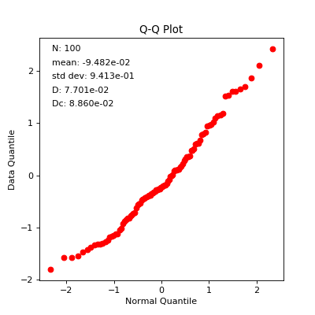

```python
Image(filename='qq.png')
```

## quick_hyst.py

[[notebook version]](http://pmagpy.github.io/PmagPy_plots_analysis.html#quick_hyst)

```
-I- Using online data model
-I- Getting method codes from earthref.org
-I- Using cached vocabularies
['mc04c-1' 'mc113a1-1' 'mc117a2-1' 'mc120a2-1' 'mc129a1-1' 'mc164a2-1'
 'mc205a1-1' 'mc217a2-1']
working on t:  273
1  saved in  McMurdo_mc04c_mc04c_mc04c-1_hyst.png
```

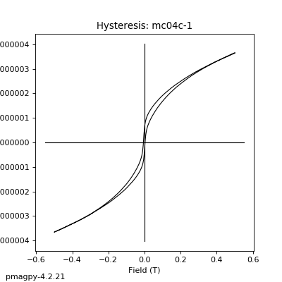

```python
!quick_hyst.py -WD data_files/3_0/McMurdo -spc mc04c-1 -fmt png
Image("McMurdo_mc04c_mc04c_mc04c-1_hyst.png")
```

## revtest.py

[[notebook version]](http://pmagpy.github.io/PmagPy_plots_analysis.html#revtest)

```python
!revtest.py -f data_files/revtest/revtest_example.txt -fmt png -sav
```

```
doing first mode, be patient
doing second mode, be patient
1  saved in  REV_X.png
2  saved in  REV_Y.png
3  saved in  REV_Z.png
```

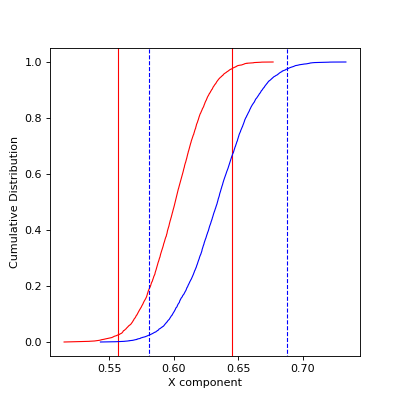

```python
Image(filename='REV_X.png')
```

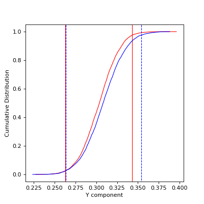

```python
Image(filename='REV_Y.png')
```

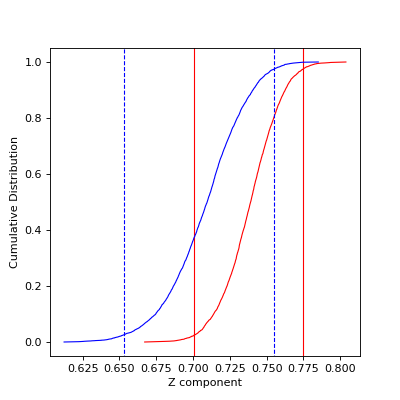

```python
Image(filename='REV_Z.png')
```

## revtest_magic.py

[[notebook version]](http://pmagpy.github.io/PmagPy_plots_analysis.html#revtest_magic)

```python
!revtest_magic.py -f data_files/revtest_magic/sites.txt -fmt png -sav -DM 3 -exc
```

```
doing first mode, be patient
doing second mode, be patient
1  saved in  REV_X.png
2  saved in  REV_Y.png
3  saved in  REV_Z.png
```

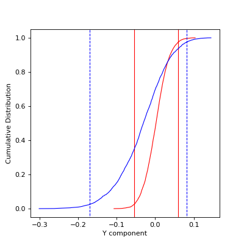

```python
Image("Rev_Y.png")
```

## s_eigs.py

[[notebook version]](http://pmagpy.github.io/PmagPy_calculations.html#s_eigs)

```python
!s_eigs.py -f data_files/s_eigs/s_eigs_example.dat
```

```
0.33127186 239.53  44.70 0.33351338 126.62  21.47 0.33521473  19.03  37.54
0.33177859 281.12   6.18 0.33218277 169.79  73.43 0.33603862  12.82  15.32
0.33046979 283.57  27.30 0.33328307 118.37  61.91 0.33624712  16.75   6.13
0.33123776 261.36  12.07 0.33377582 141.40  66.82 0.33498645 355.70  19.48
0.33085680 255.71   7.13 0.33379164 130.85  77.65 0.33535156 346.97  10.03
0.33175930 268.51  26.79 0.33405024 169.66  16.95 0.33419049  51.04  57.53
0.33194992 261.59  20.68 0.33313262  92.18  68.99 0.33491743 352.93   3.54
0.33157593 281.42  21.32 0.33312121 117.04  67.94 0.33530283  13.54   5.41
```

## s_geo.py

[[notebook version]](http://pmagpy.github.io/PmagPy_calculations.html#s_geo)

```python
!s_geo.py -f data_files/s_geo/s_geo_example.dat
```

```
0.33412680 0.33282733 0.33304587 -0.00015289 0.00124843 0.00135721
0.33556300 0.33198264 0.33245432 0.00087259 0.00024141 0.00096166
0.33584908 0.33140627 0.33274469 0.00131845 0.00118816 0.00002986
0.33479756 0.33142531 0.33377719 -0.00047493 0.00049539 0.00044303
0.33505613 0.33114848 0.33379540 -0.00101375 0.00028536 0.00034852
0.33406156 0.33226916 0.33366925 -0.00002267 0.00098548 0.00005553
0.33486596 0.33216032 0.33297369 -0.00035492 0.00039254 0.00015403
0.33510646 0.33196402 0.33292958 0.00075965 0.00057242 0.00010112
```

## s_hext.py

[[notebook version]](http://pmagpy.github.io/PmagPy_calculations.html#s_hext)

```python
!s_geo.py -f data_files/s_geo/s_geo_example.dat | s_hext.py
```

```
F =  5.79 F12 =  3.55 F23 =  3.66
N =  8  sigma =  0.000641809950
0.33505     5.3    14.7    25.5   124.5    61.7    13.3   268.8    23.6
0.33334   124.5    61.7    25.1   268.8    23.6    25.5     5.3    14.7
0.33161   268.8    23.6    13.3     5.3    14.7    25.1   124.5    61.7
```

## sio_magic.py

[[notebook version]](http://pmagpy.github.io/PmagPy_MagIC.html#sio_magic)

See irmaq_magic.py

## s_tilt.py

[[notebook version]](http://pmagpy.github.io/PmagPy_calculations.html#s_tilt)

```python
!s_tilt.py -f data_files/s_tilt/s_tilt_example.dat
```

```
0.33455709 0.33192658 0.33351630 -0.00043562 0.00092779 0.00105006
0.33585501 0.33191565 0.33222935 0.00055960 -0.00005316 0.00064732
0.33586669 0.33084923 0.33328408 0.00142266 0.00013234 0.00009203
0.33488664 0.33138493 0.33372843 -0.00056597 -0.00039085 0.00004873
0.33506602 0.33127019 0.33366373 -0.00105193 -0.00057257 -0.00029959
0.33407688 0.33177567 0.33414748 0.00007007 0.00018447 0.00005073
0.33483925 0.33197853 0.33318222 -0.00028447 0.00003518 -0.00029262
0.33513144 0.33175036 0.33311823 0.00077914 -0.00006402 0.00004612
```

## s_magic.py

```python
!s_magic.py -WD data_files/convert_2_magic/s_magic -f s_magic_example.dat
```

```
8  records written to file  /Users/nebula/Python/PmagPy/data_files/convert_2_magic/s_magic/specimens.txt
data saved in  /Users/nebula/Python/PmagPy/data_files/convert_2_magic/s_magic/specimens.txt
-I- Using online data model
-I- Couldn't connect to earthref.org, using cached method codes
-I- Using cached method codes
-I- Importing controlled vocabularies from https://earthref.org
-I- Using cached suggested vocabularies
-I- Creating new samples table with data from specimens table
-I- writing samples records to /Users/nebula/Python/PmagPy/data_files/convert_2_magic/s_magic/samples.txt
-I- 8 records written to samples file
-I- Creating new sites table with data from samples table
-I- writing sites records to /Users/nebula/Python/PmagPy/data_files/convert_2_magic/s_magic/sites.txt
-I- 1 records written to sites file
-I- overwriting /Users/nebula/Python/PmagPy/data_files/convert_2_magic/s_magic/samples.txt
-I- 8 records written to samples file
-I- overwriting /Users/nebula/Python/PmagPy/data_files/convert_2_magic/s_magic/sites.txt
-I- 1 records written to sites file
```

## scalc.py

[[notebook version]](http://pmagpy.github.io/PmagPy_calculations.html#scalc)

```python
!scalc.py -f data_files/scalc/scalc_example.txt
```

```
100    21.8    180.0
```

```python
!scalc.py < data_files/scalc/scalc_example.txt
```

```
100    21.8    180.0
```

```python
!scalc.py -f data_files/scalc/scalc_example.txt -v
```

```
89    15.2     32.3
```

```python
!scalc.py -f data_files/scalc/scalc_example.txt -v -b
```

```
89    15.2    13.4     16.7    32.3
```

## scalc_magic.py

[[notebook version]](http://pmagpy.github.io/PmagPy_calculations.html#scalc_magic)

```python
!scalc_magic.py -f data_files/scalc_magic/sites.txt -c 30
```

```
13    17.9     30.0
```

## site_edit.py

This program requires user interaction and can only be used on the command line.

## specimens_results_magic.py

This program has been superceded by Pmag GUI and is not maintained.

## stats.py

[[notebook version]](http://pmagpy.github.io/PmagPy_calculations.html#stats)

```python
!stats.py -f data_files/gaussian/gauss.out
```

```
100 9.94986999 994.9869990000003 0.9581673609207783 9.629948550923512
```

## strip_magic.py

```python
!strip_magic.py -f data_files/strip_magic/sites_with_vgps.txt -x age -y lat -fmt png -sav -DM 3
```

```
1  saved in  strat.png
```

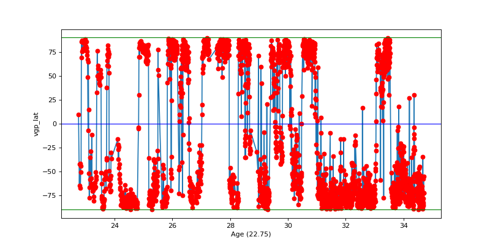

```python
Image(filename='strat.png')
```

## sundec.py

[[notebook version]](http://pmagpy.github.io/PmagPy_calculations.html#sundec)

```python
!sundec.py -f data_files/sundec/sundec_example.dat
```

```
  154.2
```

## thellier_magic.py

[[notebook version]](http://pmagpy.github.io/PmagPy_plots_analysis.html#thellier_magic)

This program is no longer maintained - you should try Thellier GUI instead.

```python
!thellier_magic.py -n 5 -WD . -ID data_files/thellier_magic -sav -fmt png
```

```
-I- Using online data model
-I- Getting method codes from earthref.org
-I- Using cached vocabularies
-W- Couldn't read in specimens data
-I- Make sure you've provided the correct file name
-W- Couldn't read in specimens data
-I- Make sure you've provided the correct file name
-W- Couldn't read in specimens data for data propagation
s2s0-01
1  saved in  /Users/nebula/Python/PmagPy/s2s0-01_arai.png
2  saved in  /Users/nebula/Python/PmagPy/s2s0-01_zijd.png
3  saved in  /Users/nebula/Python/PmagPy/s2s0-01_eqarea.png
4  saved in  /Users/nebula/Python/PmagPy/s2s0-01_deremag.png
s2s0-02
1  saved in  /Users/nebula/Python/PmagPy/s2s0-02_arai.png
2  saved in  /Users/nebula/Python/PmagPy/s2s0-02_zijd.png
3  saved in  /Users/nebula/Python/PmagPy/s2s0-02_eqarea.png
4  saved in  /Users/nebula/Python/PmagPy/s2s0-02_deremag.png
s2s0-03
1  saved in  /Users/nebula/Python/PmagPy/s2s0-03_arai.png
2  saved in  /Users/nebula/Python/PmagPy/s2s0-03_zijd.png
3  saved in  /Users/nebula/Python/PmagPy/s2s0-03_eqarea.png
4  saved in  /Users/nebula/Python/PmagPy/s2s0-03_deremag.png
s2s0-04
1  saved in  /Users/nebula/Python/PmagPy/s2s0-04_arai.png
2  saved in  /Users/nebula/Python/PmagPy/s2s0-04_zijd.png
3  saved in  /Users/nebula/Python/PmagPy/s2s0-04_eqarea.png
4  saved in  /Users/nebula/Python/PmagPy/s2s0-04_deremag.png
s2s0-05
1  saved in  /Users/nebula/Python/PmagPy/s2s0-05_arai.png
2  saved in  /Users/nebula/Python/PmagPy/s2s0-05_zijd.png
3  saved in  /Users/nebula/Python/PmagPy/s2s0-05_eqarea.png
4  saved in  /Users/nebula/Python/PmagPy/s2s0-05_deremag.png
```

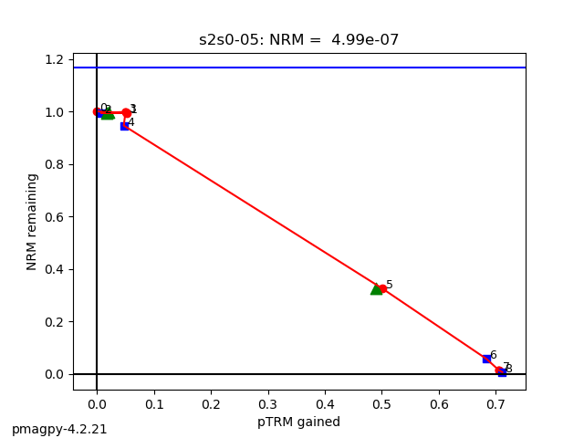

```python
Image("s2s0-05_arai.png")
```

## thellier_magic_redo.py

The function of this program has been incorporated into Thellier GUI so you should use that instead.

## tk03.py

[[notebook version]](http://pmagpy.github.io/PmagPy_calculations.html#tk03)

```python
!tk03.py -lat 30 > data_files/tk03/tk03.out
!eqarea.py -f data_files/tk03/tk03.out -fmt png -sav
```

```
1  saved in  tk03_eq.png
```

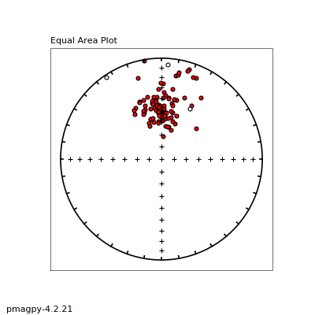

```python
Image(filename='tk03_eq.png')
```

## trmaq_magic.py

```python
!trmaq_magic.py -ft data_files/3_0/McMurdo/specimens.txt \
    -f data_files/3_0/McMurdo/measurements.txt -sav -fmt png
```

[output not shown]

[output cut: 1365 more lines]

[output not shown]

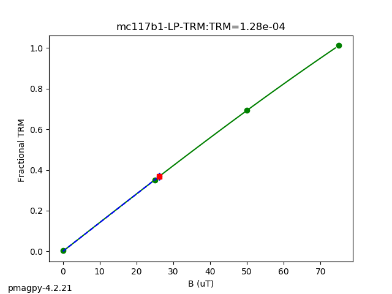

```python
Image("mc117b1_TRM.png")
```

## uniform.py

[[notebook version]](http://pmagpy.github.io/PmagPy_calculations.html#uniform)

```python
!uniform.py -n 50
```

```
  173.2    37.7
  217.2   -17.2
  220.6   -27.5
  163.5     8.0
  304.4    -6.6
  166.9    69.4
  167.4   -12.4
  275.1    23.8
  160.5    24.3
   42.1    28.3
  116.2    -7.0
  188.3   -67.3
  211.6    47.2
  324.9     6.3
   32.4   -71.9
    6.8   -33.7
   24.7    41.0
  188.8    48.0
   73.4   -66.7
    9.6    31.9
  259.9   -25.7
  212.9    59.3
  285.2   -11.0
   71.6    -8.6
  339.2   -25.9
  214.6    76.5
  164.3   -41.2
   33.2    61.7
   64.4   -56.7
   18.0    -7.3
    3.4   -55.3
  127.0     7.9
  122.5     6.9
   47.6   -17.4
   56.4   -49.8
  200.7    -3.8
  243.8    80.0
  118.9     6.0
  326.9   -27.9
  114.9   -36.8
  126.6   -27.0
  173.5    56.6
   41.0    39.5
  109.2    16.6
   58.2    19.6
  216.6    25.3
  281.9    68.2
  284.2    22.4
  222.8    47.0
  356.4   -33.6
```

```python
!uniform.py -n 50 > data_files/uniform/uniform.out
!eqarea.py -f data_files/uniform/uniform.out -fmt png -sav
```

```
1  saved in  uniform_eq.png
```

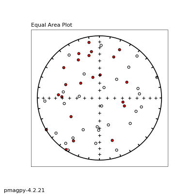

```python
Image(filename='uniform_eq.png')
```

## update_measurements.txt

This program has been superceded by Pmag GUI, so you should use that.

## upload_magic.py

[[notebook version]](http://pmagpy.github.io/PmagPy_MagIC.html#upload_magic)

program has been superceded by Pmag GUI, so you should use that.

## utrecht_magic.py

[[notebook version]](http://pmagpy.github.io/PmagPy_MagIC.html#utrecht_magic)

```python
!utrecht_magic.py -f data_files/convert_2_magic/UTRECHT_magic/Utrecht_Example.af
```

```
-I- Using online data model
-I- Getting method codes from earthref.org
-I- Using cached vocabularies
adding measurement column to measurements table!
-I- overwriting /Users/nebula/Python/PmagPy/measurements.txt
-I- 350 records written to measurements file
-I- overwriting /Users/nebula/Python/PmagPy/specimens.txt
-I- 25 records written to specimens file
-I- overwriting /Users/nebula/Python/PmagPy/samples.txt
-I- 3 records written to samples file
-I- overwriting /Users/nebula/Python/PmagPy/sites.txt
-I- 3 records written to sites file
-I- overwriting /Users/nebula/Python/PmagPy/locations.txt
-I- 1 records written to locations file
-I- overwriting /Users/nebula/Python/PmagPy/measurements.txt
-I- 350 records written to measurements file
```

## vdm_b.py

[[notebook version]](http://pmagpy.github.io/PmagPy_calculations.html#vdm_b)

```python
!vdm_b.py -f data_files/vdm_b/vdm_b_example.dat
```

```
 3.300e-05
```

```python
!cat data_files/b_vdm/b_vdm_example.dat
```

```
33 22
```

## vector_mean.py

[[notebook version]](http://pmagpy.github.io/PmagPy_calculations.html#vector_mean)

```python
!vector_mean.py -f data_files/vector_mean/vector_mean_example.dat
```

```
    1.3    49.6    2.289e+06 100
```

## vgp_di.py

[[notebook version]](http://pmagpy.github.io/PmagPy_calculations.html#vgp_di)

```python
!vgp_di.py -f data_files/vgp_di/vgp_di_example.dat
```

```
  335.6    62.9
```

## vgpmap_magic.py

[[notebook version]](http://pmagpy.github.io/PmagPy_plots_analysis.html#vgpmap_magic)

```python
!vgpmap_magic.py -WD data_files/3_0/McMurdo -f sites.txt -crd g -prj ortho -eye 60 0  -sym ko 10 -fmt png -S -sav
```

```
-I- Using cached data model
-I- Getting method codes from earthref.org
-I- Using cached vocabularies
-I- Using cached suggested vocabularies
gridlines only supported for PlateCarree, Lambert Conformal, and Mercator plots currently
1  saved in  McMurdo_VGP_map.png
```

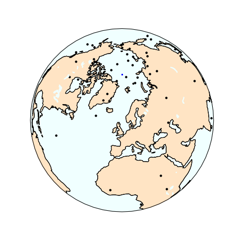

```python
image = None
if cartopy_present:
    image = Image("McMurdo_VGP_map.png")
image
```

## watsons_f.py

[[notebook version]](http://pmagpy.github.io/PmagPy_calculations.html#watsons_f)

```python
!watsons_f.py -f data_files/watsons_f/watsons_f_example_file1.dat \
-f2 data_files/watsons_f/watsons_f_example_file2.dat
```

```
   5.23    3.26
```

## watsons_v.py

[[notebook version]](http://pmagpy.github.io/PmagPy_plots_analysis.html#watsons_v)

```python
!watsons_v.py -f data_files/watsons_f/watsons_f_example_file1.dat \
-f2 data_files/watsons_f/watsons_f_example_file2.dat -fmt png -sav
```

```
Watson's V,  Vcrit:
         10.5        6.5
1  saved in  watsons_v_watsons_f_example_file1_watsons_f_example_file2.png
```

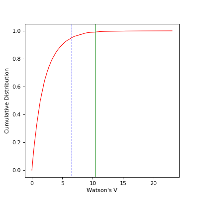

```python
Image(filename="watsons_v_watsons_f_example_file1_watsons_f_example_file2.png")
```

## zeq.py

[[notebook version]](http://pmagpy.github.io/PmagPy_plots_analysis.html#zeq)

This program requires interaction and can only be run from the command line.

## zeq_magic.py

[[notebook version]](http://pmagpy.github.io/PmagPy_plots_analysis.html#zeq_magic)

##### Note: This program is no longer maintained. It has been superceded by demag_gui.py

```
-I- Using online data model
-I- Couldn't connect to earthref.org, using cached method codes
-I- Using cached method codes
-I- Importing controlled vocabularies from https://earthref.org
-I- Using cached suggested vocabularies
1  saved in  mc01f_eqarea.png
2  saved in  mc01f_zijd.png
3  saved in  mc01f_demag.png
```

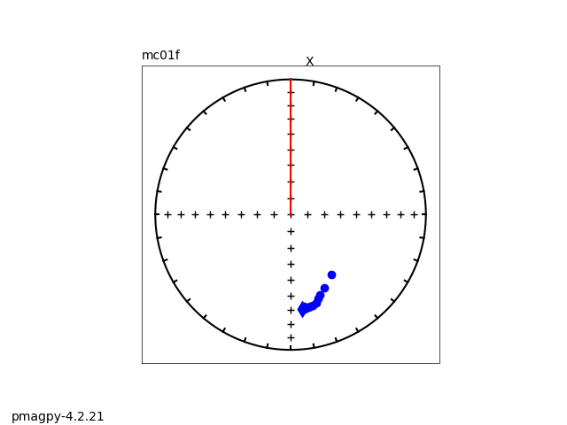

```python
!zeq_magic.py -WD data_files/3_0/McMurdo -new -sav -spc mc01f -fmt png -new
Image('mc01f_eqarea.png')
```